# Collection of useful topics

## Outline

- Exponents
- Logs
- Summations
- Implications
- Proofs
- Set Theory
- Induction

## Rules of exponents

\begin{align*} x^m(x^n) &= x^{m+n} & \dfrac{x^m}{x^n} &= x^{m-n} \\ \\ (x^m)^n &= x^{mn} & (xy)^m &= x^m y^m \\ \\ (\dfrac{x}{y})^m &= \dfrac{x^m}{y^m} & \dfrac{1}{x^m} &= x^{-m} \\ \\ \sqrt{x} &= x^{1/2} & \sqrt[m]{x} &= x^{1/m} \\ \\ \sqrt[n]{x^m} &= x^{m/n} & x^{-(m/n)} &= \dfrac{1}{x^{m/n}} \end{align*}

### Exercise

Simplify the following, using the rules of exponents.

🐑 $x^4 x^5$

🐑 $x^7 x^{-3}$

🐑 $x^2 x^{\frac{1}{2}}$

🐑 $\dfrac{x^4}{x^7}$

🐑 $\dfrac{x^3}{\sqrt{x}}$

🐑 $(x^4)^{-2}$

## Exponents and Logs

Assuming $a,b>0$, $a,b \neq 1$, and $a$ and $y$ are any real numbers:

\begin{align*} a^x(a^y) &= a^{x+y} & \dfrac{a^x}{a^y} &= a^{x-y} & \dfrac{1}{a^x} &= a^{-x} \\ \\ (a^x)^y &= a^{xy} & (ab)^x &= a^x b^x & (\dfrac{a}{b})^x &= \dfrac{a^x}{b^x} \end{align*}

For $a$, $x$, and $y$ positive real numbers, $n$ a real number, and $a \neq 1$:

\begin{align*} \log_a xy &= \log_a x + \log_a y & \log a x^n &= n \log_a x \\ \\ \log_a \dfrac{x}{y} &= \log_a x - \log_a y & \log_a \sqrt[n]{x} &= \dfrac{1}{n} \log_a x \end{align*}

And what base should we use for the log?

Generally use the base $e$.

$e = \lim_{n\to\infty} \bigg( 1 + \dfrac{1}{n} \bigg) ^n \approx 2.71828 $

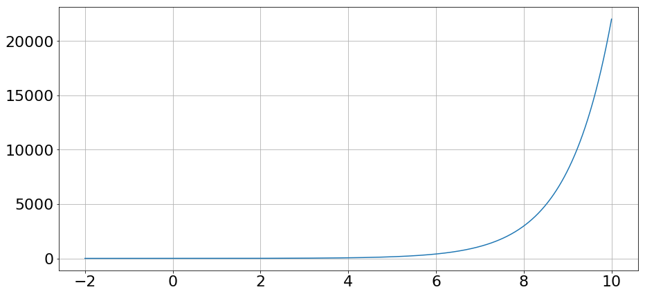

```python
graph('np.exp(x)',-2,10)
```

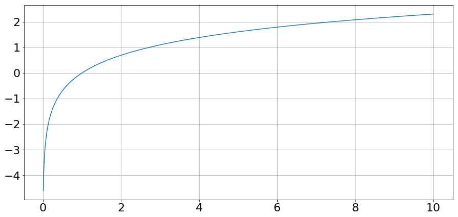

```python
graph('np.log(x)',0.01,10)
```

Why do economists like logs?

- Transform nonlinear functions into linear functions.
- Logs can be intepreted as a percentage change.

### Exercise

🐑 Find possible exponential functions for the graphs in Fig. 4 (SHS, page 119).

🐑 With $f(t) = Aa^t$, if $f(t +t^∗) = 2f(t)$, prove that $a^{t^∗} = 2$. (This shows that the doubling time $t^∗$ of the general exponential function is independent of the initial time t.)

🐑 Recall that the doubling time $t^∗$ of an exponential function $f(t) = Aa^t$ is given by the formula $a^{t^∗} =2$. Solve this equation for $t^∗$.

🐑 Prove that $\log_a(x/y) = \log_a x - \log_a y$.

## Summations

$$\sum _{i{\mathop {=}}m}^{n}a_{i}=a_{m}+a_{m+1}+a_{m+2}+\cdots +a_{n-1}+a_{n}$$

Identities:

$\sum _{n=s}^{t}C\cdot f(n)=C\cdot \sum _{n=s}^{t}f(n)$, where C is a constant

$\sum _{n=s}^{t}f(n)+\sum _{n=s}^{t}g(n)=\sum _{n=s}^{t}\left[f(n)+g(n)\right]$

$\sum _{n=s}^{t}f(n)-\sum _{n=s}^{t}g(n)=\sum _{n=s}^{t}\left[f(n)-g(n)\right]$

And lots [more](https://en.wikipedia.org/wiki/Summation#Identities).

### Exercises

Compute the following:

🐑 $\sum_{i=1}^5 i^2$

🐑 $\sum_{k=3}^6 (5k-3)$

🐑 $\sum_{j=0}^2 \dfrac{(-1)^j}{(j+1)(j+3)}$

Write the following sums using summation notation:

🐑 $1 + 3 + 3^2 + 3^3 + ··· + 3^{81}$

🐑 $a^6_i + a^5_i b_j + a^4_i b^2_j + a^3_i b^3_j + a^2_i b^4_j + a_ib^5_j + b^6_j$

🐑 Evaluate the sum $\sum^n_{m=2} \dfrac{1}{(m-1)m}$ by using the identity $\dfrac{1}{(m-1)m} = \dfrac{1}{m-1} - \dfrac{1}{m}$.

## A bit of logic

Find a solution for the equation $x + 2 = \sqrt{4 − x}$.

Why did we go wrong?

\begin{align} x+2 &= \sqrt{4-x} &\implies \\ (x+2)^2 &= 4-x &\implies \\ xˆ2 + 4x + 4 &= 4 - x &\implies \\ x^2 + 5x &= 0 &\implies \\ x(x+5) &= 0 &\implies \\ x = 0 \text{ or } x = -5 & & \end{align}

### Some notation to remember

$P \implies Q$

- P implies Q
- if P, then Q
- Q is a consequence of P
- P is a sufficient condition for Q

$ P \impliedby Q $

- P only if Q
- P is a necessary condition for Q

$ P \iff Q $

- P if and only if Q
- P is a necessary and sufficient condition for Q.

### Exercises

🐑 SHS Page 65: Exercise 1-8

## Mathematical Proofs

Direct vs indirect proof:

- $P \implies Q$ is equivalent to $\text{not } Q \implies \text{not } P$.

*If it is raining, the grass is getting wet.*

*If the grass is not getting wet, then it is not raining.*

Use the two methods of proof to prove that $−x2+5x−4>0 \implies x >0$.

## Set Theory

Specify all the elements:

$F = \{\text{fish, pasta, omelette, chicken}\}$

Specify property:

$B = \{(x,y): px+qy \leq m, x \geq 0, y \geq 0 \}$

### Set membership

$ x \in A $ the element $x$ is in $A$.

$ A \subseteq B $ subset, all elements of $A$ are in $B$

$ A \subset B $ proper subset, all elements of $A$ are in $B$, and $B$ contains at least one element not in $A$

$ A \supseteq B $ superset , $A$ contains all elements in $B$

$ A \supset B $ proper superset, $A$ contains $B$ as well as at least one element not in $B$.

### Set operations

$ A \cup B $ The elements that belong to at least one of the sets A and B

$ A \cap B $ The elements that belong to both A and B

$ A \setminus B $ The elements that belong to A, but not to B

### Exercise

Let $A={1,2,3,4,5}$ and $B={3,6}$. Find $A \cup B$, $A \cap B$, $A \setminus B$, and $ B \setminus A$.

### Venn Diagrams

Graphical representation of three or more sets.

See diagrams on SHS Page 72.

## Homework

🐑 SHS Page 126: Exercise 21, 22

🐑 SHS Page 77-78: Exercise 1-10